# The Plant Body

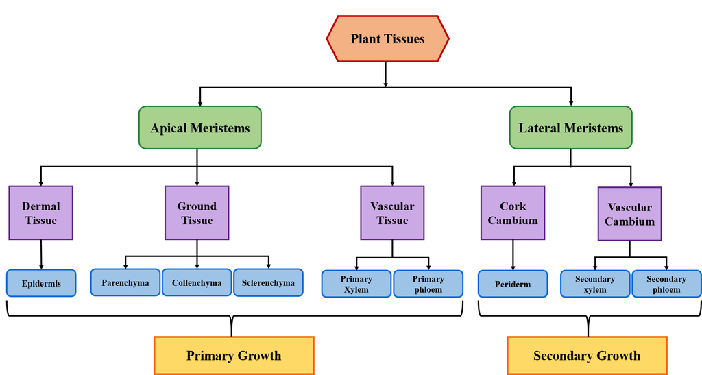

## Themes in plant form

- **Plants gather materials to grow**
  - soil
  - atmosphere
  - materials can be limiting
- **Above and belowground body plan**

[figure not shown]

## Themes in plant form

- **Plants gather materials to grow**
  - soil
  - atmosphere
  - materials can be limiting
- **Above and belowground body plan**
- **Plants exhibit indeterminate growth**
  - “foragers”
  - diversity of size & shape
  - add rigid support to expanding tissues

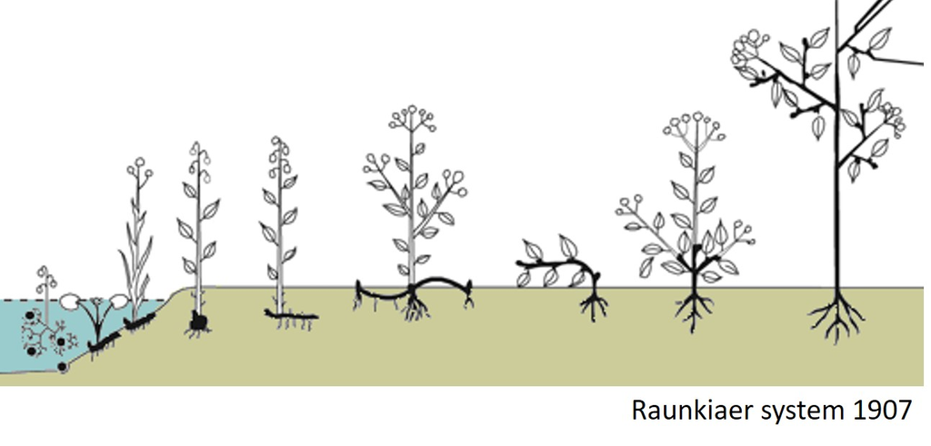

## Plants do all this without moving!

- **Mostly defined by their total inability to move**
- **Is this a good thing or a bad thing?**
- *Their Darwinian struggle for growth, survival and reproduction in very different arenas has resulted in an extremely wide variety of form and function (Diaz et al 2016)*

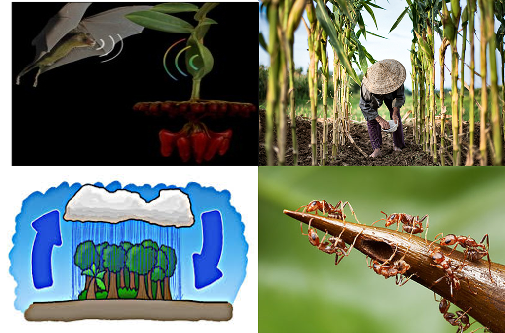

[figure not shown]

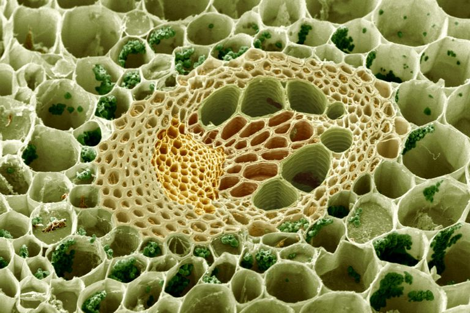

## Dermal (1) tissue (aka ‘Skin’)

- **Outer layer in young/non-woody plants = epidermis**
  - single layer of flattened cells
- **Woody plants epidermis cracks because of *vascular cambium* growth and must be replaced**
  - repaired by *cork cambium*
  - new layer is called *periderm*
  - whole thing called ‘cork’
    - non botany = bark

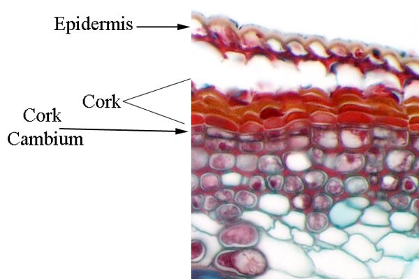

## Wine cork = periderm from *Quercus suber*

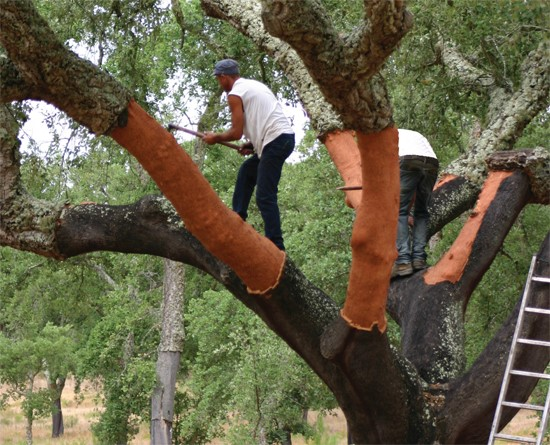

[figure not shown]

## Epidermal cells secrete ‘cutin’

- **Wax-like substances that forms the ‘cuticle’**
  - prevents evaporative water loss
  - makes the plant water proof
- **Often thick enough to make leaf shiny**
  - succulents & tropical plants

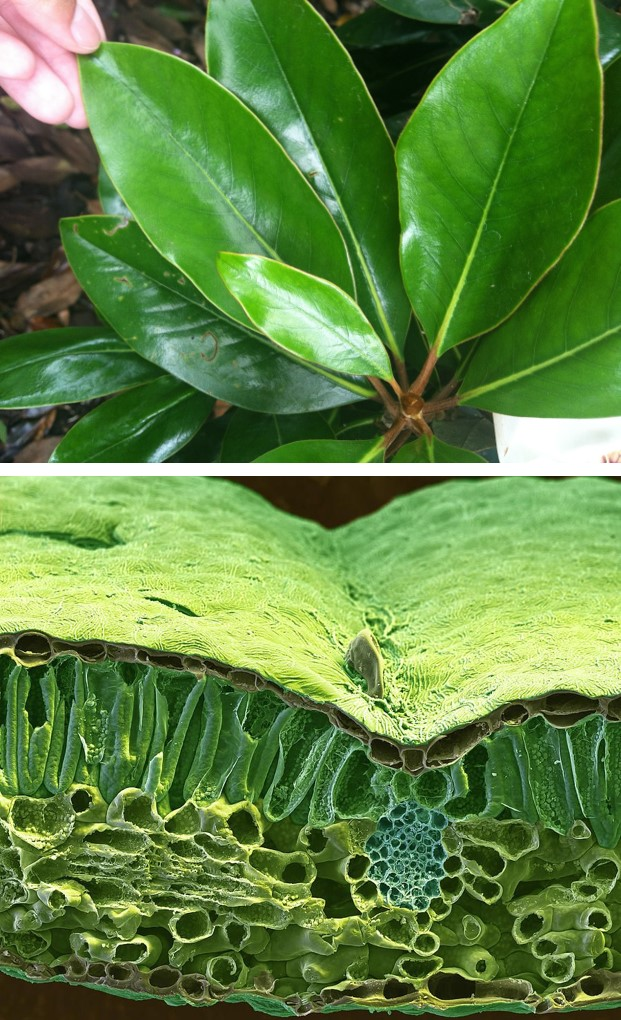

## Epidermal cells secrete ‘cutin’

- **Wax-like substances that forms the ‘cuticle’**
  - prevents evaporative water loss
  - makes the plant water proof
- **Trichomes may also be present on epidermis**
  - hairs (sometimes glandular)
- **Trichomes have lots of roles:**
  - protection from herbivores and pathogens
  - regulation of water loss
  - reflection of UV radiation
  - production of chemical compounds like oils, resins, and cannabinoids

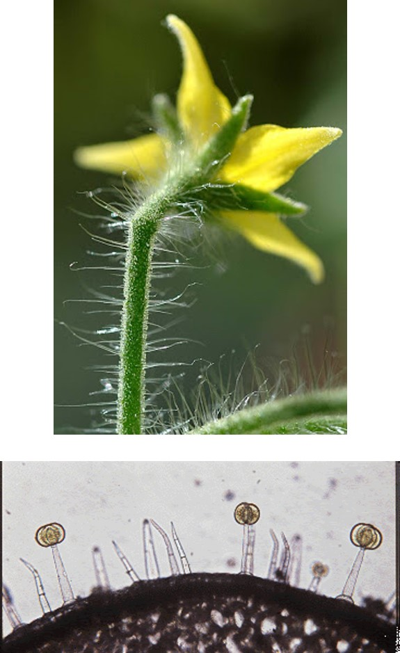

## Stomata are scattered within leaf epidermis

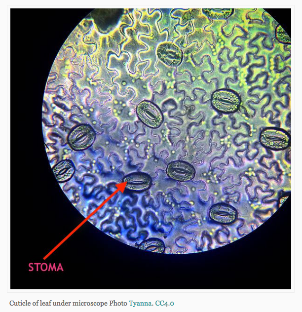

- **Stoma (Stomata = plural) are pores that allow gas exchange**
  - CO<sub>2</sub>, O<sub>2</sub>, water vapor
- **Essential since plant is ‘water proof’**
- **Pair of guard cells shrink/swell to open/close (create stoma)**
  - guard cells are specialized epidermal cells
  - *much more later…*
- **In microscope images, you can often see stoma embedded in the waxy cuticle**

## Physiology preview: Opening stomata is a delicate balance

**Evolution preview: Stomatal behavior/control a key factor in seed plant dominance**

[figure not shown]

[figure not shown]

## Ground (2) Tissues make up bulk of non-woody plant organs

- **Parenchyma = thin walled & most versatile**
  - metabolically active cells
  - photosynthetic cells in green tissues
  - storage cells (water, starch) in other organs
- **Collencyhma = primary support cells**
  - elongated & thick cell walls
  - living cells below epidermis
  - flexible
- **Schlerenchyma = mechanical support & protection**
  - rigid & very thick cell walls
  - dead @ maturity
  - used to make cloth and rope

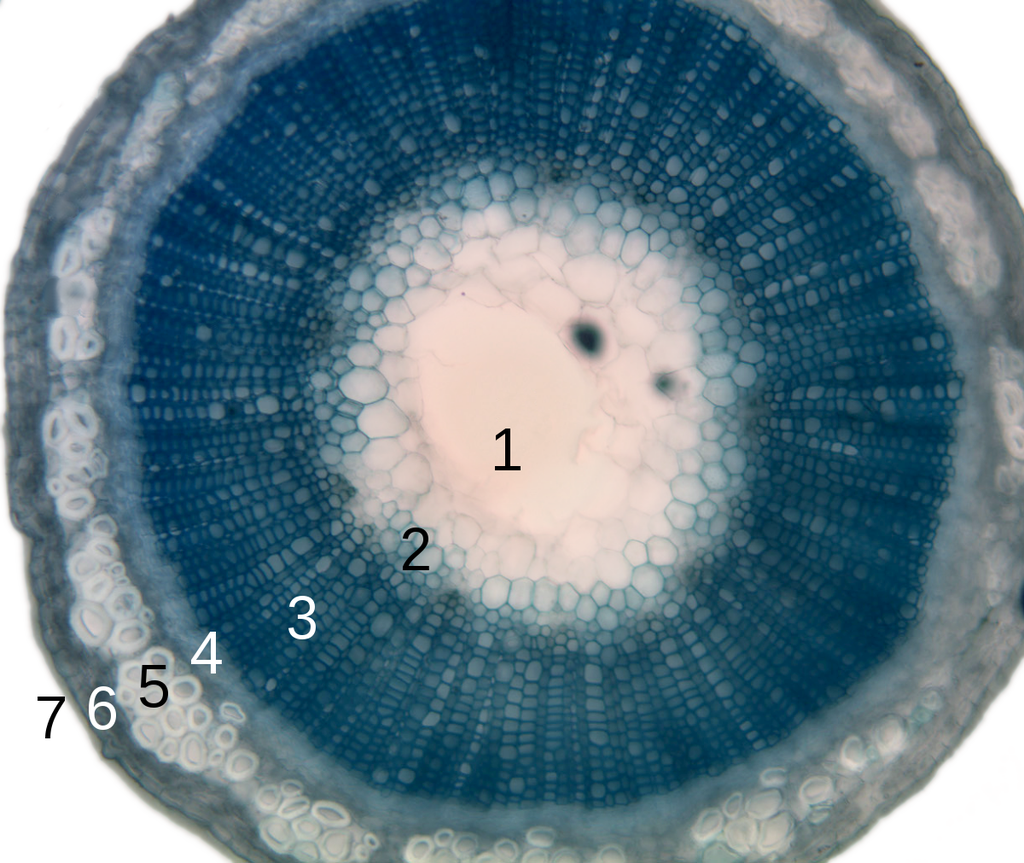

## Parenchyma cells: living, dividing with metabolic function

[figure not shown]

## Collenchyma (flexible) & Sclerenchyma (rigid) for support

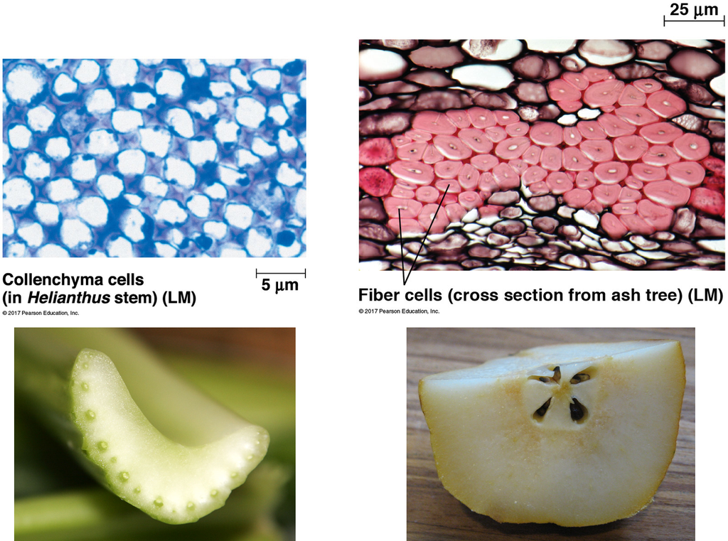

## Vascular (3) Tissues

- **Conducting tissues in plants**
  - visible in leaves = veins!
- **Two tissues systems allow movement of materials**
  - created from apical and lateral meristems
- **Xylem cells = water and minerals from roots upward**
- **Phloem cells = organic materials from leaf to rest of plant**

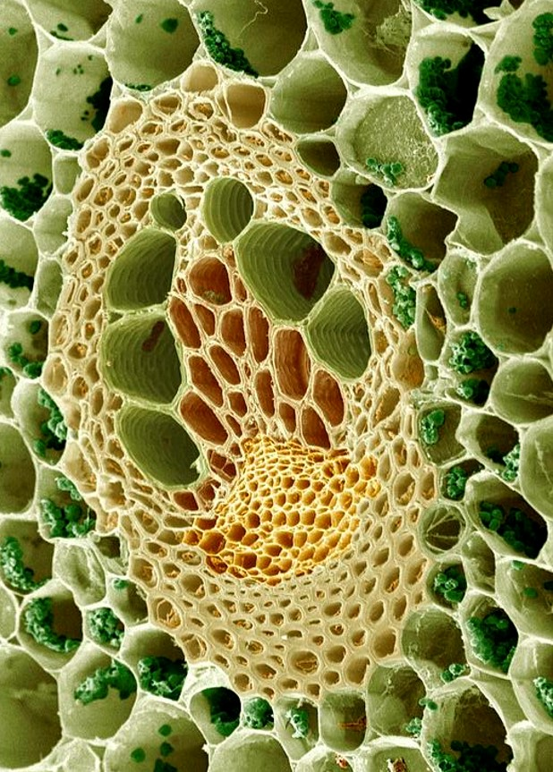

## Pipe Theory works to visual continuum

**Pipe theory = simple model that treats plant vascular tissues like bundles of pipes**  
**Allows us to model how plant form and function are constrained by transport efficiency**

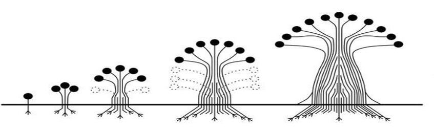

## Tracheids and vessels are conducting xylem cells

- **Both are dead at maturity, with just cell walls (bulk of ‘wood’)**
- **Tracheids = long, thin & tapered**
  - many pits in cell walls that connect to other tracheids
  - have thin membranes (pits) that allow water movement but not air bubbles/pathogens
  - found in all vascular plants
- **Vessels = short, wide & end to end**
  - pits have thinner borders than in tracheids (only on sides)
    - allows faster water movement but more vulnerable to air bubbles
  - perforation plates exists at ends of cell walls
    - membrane breaks down, so water freely flows vertically
  - unique to angiosperms

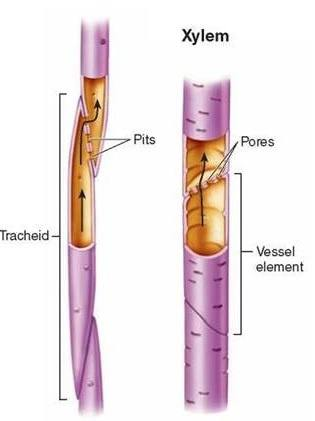

## Sieve tube members make up phloem

- **Living cells with only primary cell wall**
  - nucleus/organelles eventually disappear
- **Sieve plates = end walls with large pores**
- **Each seive tube has a companion cell**
  - developmentally tied together
  - lots of plasmodesmata connect 2 cells
  - loads and unloads sugars

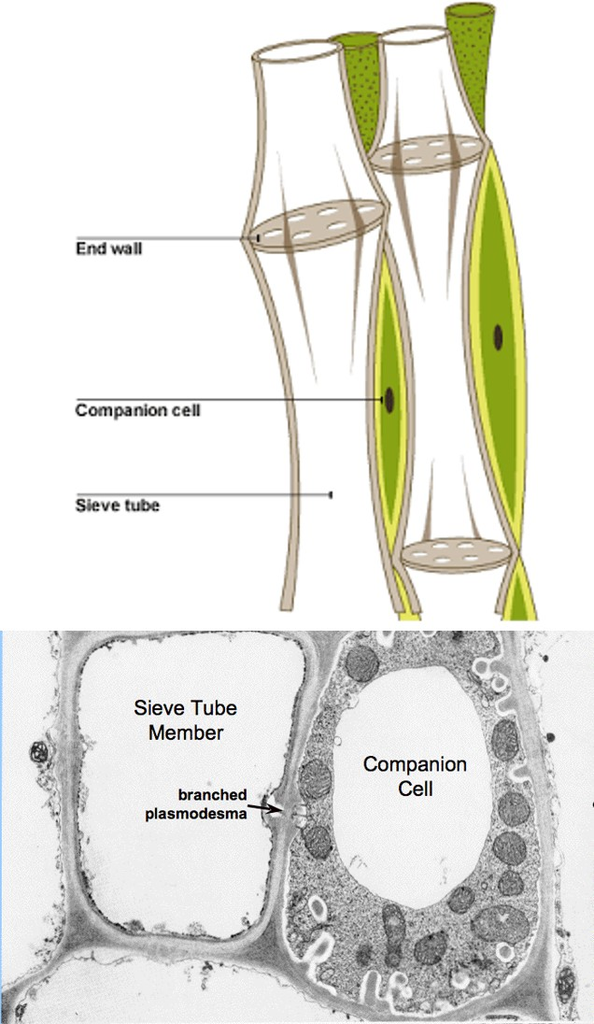

## Vascular tissues sometimes wrapped in *bundle sheath* cells

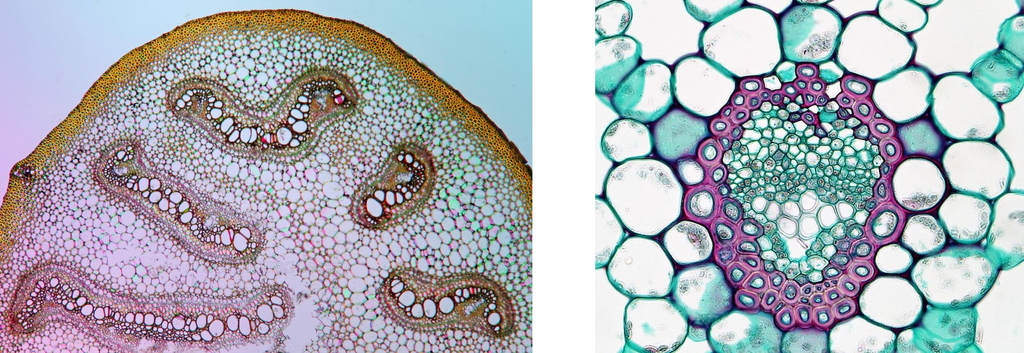

## Plant organs are easy: Stems, roots & leaves

- **Roots: tap and fibrous root systems**
  - tap = one large root with small branches
  - fibrous = no central main root (grasses)
- **Stems: mostly ground tissue**
  - mostly xylem in woody plants
  - inner cambium = xylem = tree ring
  - when tree grows quick = xylem are large
- **Leaves: photosynthetic machines**
  - flat blade (mostly)
  - many shapes and sizes
- **Flower = modified ‘shoot’**

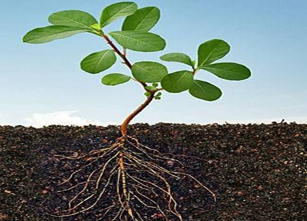

## Test yourself….this image is not a leaf….

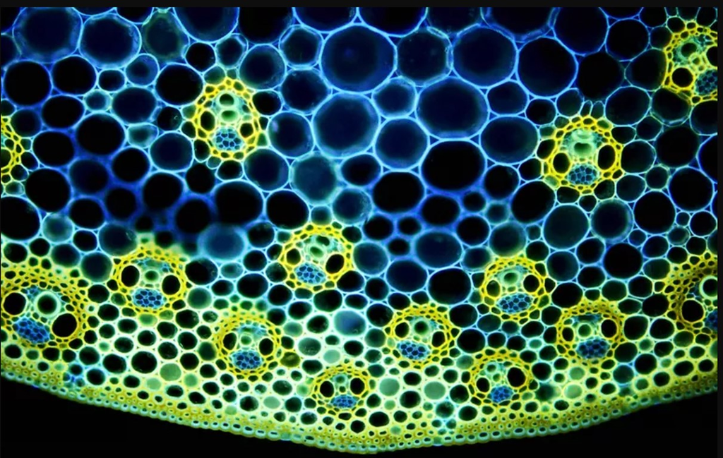

## Test yourself….this image is a leaf….

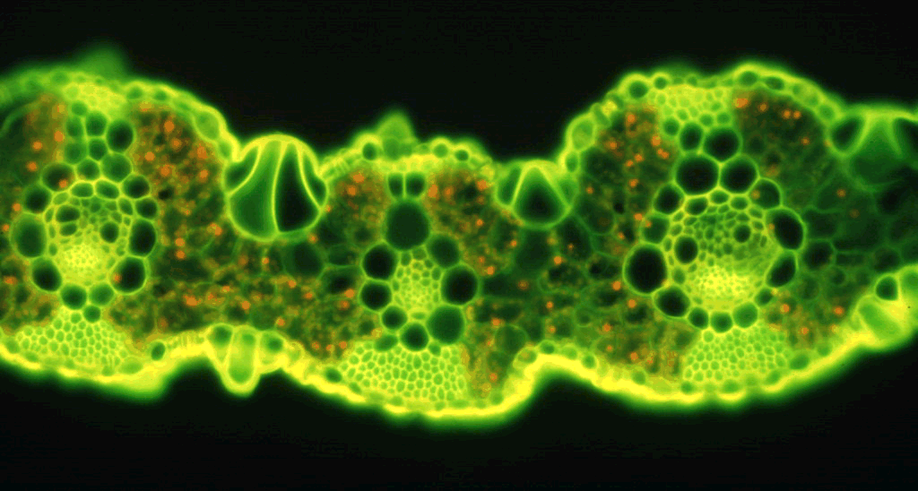